# product_selection_new_ui_report

title: Deep dive - UX of new product selection flow.  
author: Fabio Schmidt-Fischbach  
date: 2020-06-17  
region: EU  
tags: product selection, deep dive, premium, tier

## Summary

Business vs private

- 41% of users explore the Business section of the product selection funnel (e.g. click on "Yes" on the account purpose screen).
- 25% of those revert back and end up with a private account.

How do users navigate the tier selection screens?

- 70% of users start viewing the standard product as their first choice.
- 77% of users only view a single tier <-> only 23% of customers consider more than a single product before making their choice.

How is the funnel conversion working? Where are issues?

- Overall, conversion of prodcut selection is > 90%.
- 46% of customers that fail, fail on the first screen.

### Business vs standard : how many users explore the business section?

The first step of product selection is business vs standard. Do people even consider our Business products? Yes, 41% of our users explore the Business product at some point.

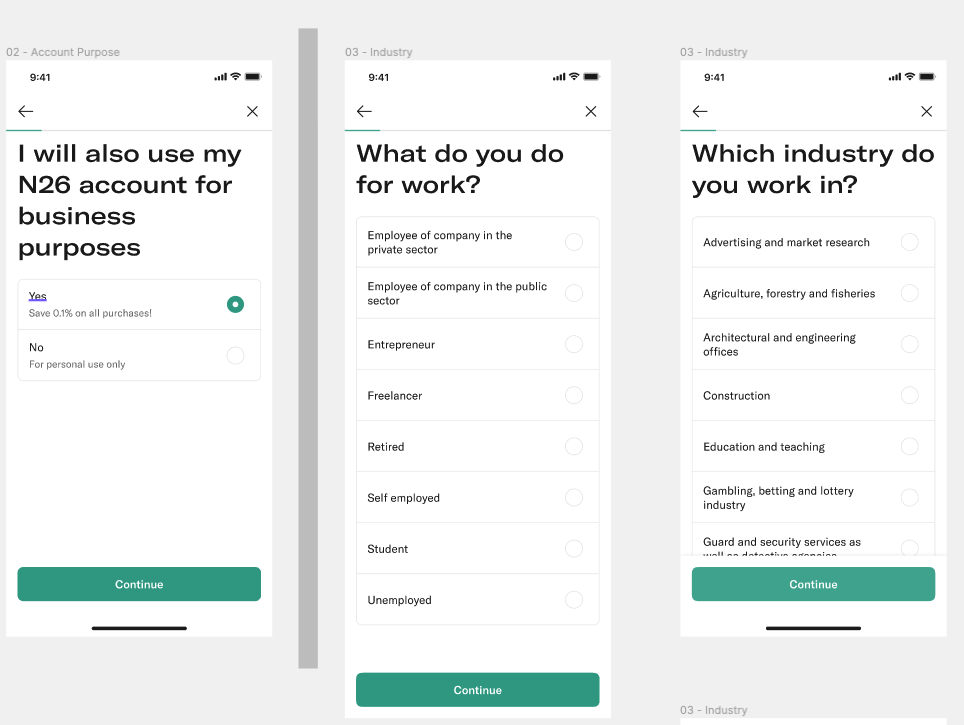

[interactive chart not shown]

|  | b | id | perc |
| --- | --- | --- | --- |
| 0 | False | 19896 | 58.395703 |
| 1 | True | 14175 | 41.604297 |

They explore Business, but do they also end up with it? 75% of users that explore Business also end up with it: 25% of them revert and end up with a private account.

[interactive chart not shown]

### Selecting the right product: how do users navigate the detail pages?

The following analysis will drop all desktop traffic (as they have a different layout).

[figure not shown]

Almost 70% of our users start viewing our standard product.

[interactive chart not shown]

It's bad news that almost 70% of our customers start with the Standard product. Ideally, we want our users to explore the premium products. The next question is how often they view another product! It shows the % of users that looked at 1,2,3 etc. different tiers.

- 77% of users only look at a single tier.
- 11% look at 2/3 tiers respectively.

[interactive chart not shown]

|  | se_label | id | perc |
| --- | --- | --- | --- |
| 0 | 1 | 9547 | 77.016780 |
| 1 | 2 | 1371 | 11.060019 |
| 2 | 3 | 1438 | 11.600516 |
| 3 | 4 | 18 | 0.145208 |
| 4 | 5 | 20 | 0.161342 |

Depending on your first product viewed, what's your most likely next step?

- 58% of those that start with Standard look at no further product.

[interactive chart not shown]

### Understanding conversion in the product selection funnel. Where do users drop off?

I already showed the first screens: account purpose (business or non-business) and detail screen.

We then moved on to explore people switching across tiers in the section above.

After this users choose the colour of their card, a delivery method and hopefully confirm their purchase on the last screen.

[figure not shown]

The first thing to understand how many people we loose in the first place. Below you see that our product selection conversion ranges above 90%.

[interactive chart not shown]

On which screens do we loose customers? The next graph shows for each screen what % of users failed on a particular screen.

Definition of failing on a screen = the screen is the last screen we record for this user.

[interactive chart not shown]

|  | se_label | id | perc |
| --- | --- | --- | --- |
| 0 | DELIVERY | 394 | 10.965767 |
| 1 | DESIGN | 35 | 0.974116 |
| 2 | DETAIL | 706 | 19.649318 |
| 3 | PREVIEW | 562 | 15.641525 |
| 4 | TERMS | 107 | 2.978013 |
| 5 | account-purpose-industries | 79 | 2.198720 |
| 6 | account-purpose-occupations | 26 | 0.723629 |
| 7 | account-purpose-preselected-occupations | 3 | 0.083496 |
| 8 | account-purpose-type | 1681 | 46.785416 |

### Linking funnel behaviour of a user to real outcomes (activation, KYC completion).

This is the natural next step. Since the new UX is only live for a short amount of time we should revisit this later.